# DATA 599 - Survival Analysis HW6 - Charles Hanks

Due: March 3, 2023

** CHANGE YOUR NAME IN THE TITLE AND COMPLETE THE FOLLOWING: **

# DATASET: NIST-arrALT.txt

**Source:** [NIST Engineering Handbook](https://www.itl.nist.gov/div898/handbook/apr/section4/apr421.htm#Graphical%20Estimation:%20Arrhenius%20Model)

Component life tests were run at three temperatures: 85°C, 105°C and 125°C. The lowest temperature cell was populated with 100 components; the 105°C cell had 50 components and the highest stress cell had 25 components. All tests were run until either all the units in the cell had failed or 1000 hours was reached. Acceleration was assumed to follow an Arrhenius model and the life distribution model for the failure mode was believed to be Weibull. The normal operating temperature for the components is 25°C. Failure analysis confirmed that all failures were due to the same failure mechanism .

Please read in the dataset, name it `ds`, and do the following:

## A

Plot KM survival curves for each temperature level.

```r
ds = read_csv('NIST-arrALT.txt')
```

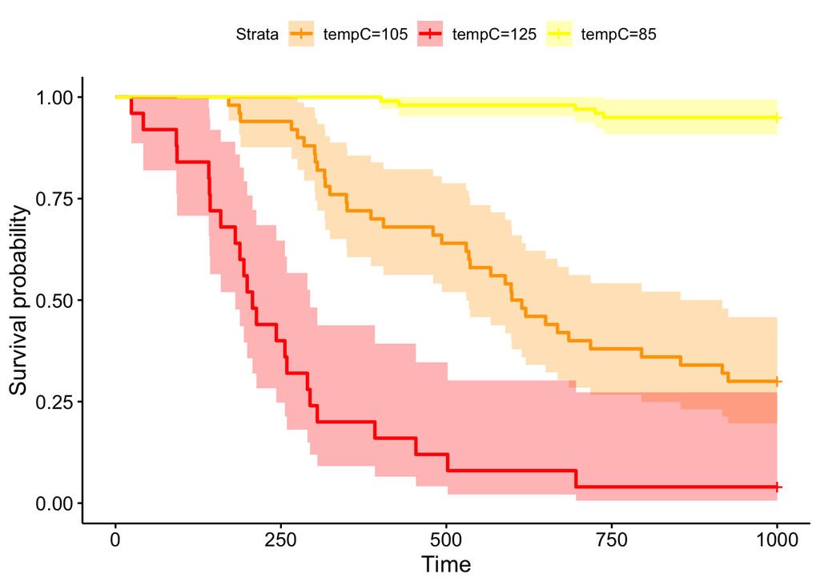

```r
km = survfit(Surv(ds$failTime,ds$status) ~ ds$tempC)

ggsurvplot(fit = km, data = ds, palette = c("orange", "red", "yellow"), risk.table = F, conf.int = T)
```

## B

For each temperature level, fit a Weibull distribution to the failure time data.

```r
ds = ds %>%
  mutate(left = failTime,
         right = ifelse(status == 0, NA, failTime))

interval.85 = ds %>% filter(tempC == 85) %>%
                    dplyr::select(left, right)

interval.105 = ds %>% filter(tempC == 105) %>%
                    dplyr::select(left, right)

interval.125 = ds %>% filter(tempC == 125) %>%
                    dplyr::select(left, right)

weibull.85 = fitdistcens(data.frame(interval.85), "weibull")
weibull.105 = fitdistcens(data.frame(interval.105), "weibull")
weibull.125 = fitdistcens(data.frame(interval.125), "weibull")

summary(weibull.85)
```

```
## Fitting of the distribution ' weibull ' By maximum likelihood on censored data
## Parameters
##         estimate   Std. Error
## shape    1.84728    0.8252175
## scale 4978.29039 3793.0922437
## Loglikelihood:  -53.62937   AIC:  111.2587   BIC:  116.4691
## Correlation matrix:
##            shape      scale
## shape  1.0000000 -0.9481008
## scale -0.9481008  1.0000000
```

```r
?fitdistcens()
```

## C

What are the $\beta$ values from your temperature-level distribution fits?

```r
summary(weibull.85)$estimate[1]
```

```
##   shape
## 1.84728
```

```r
summary(weibull.105)$estimate[1]
```

```
##    shape
## 1.702686
```

```r
summary(weibull.125)$estimate[1]
```

```
##    shape
## 1.342598
```

## D

Based on your answer in C, is it reasonable to assume that the general nature of the failures (i.e. infant mortality, exponential, or wearout) is the same for all temperature levels? Why or why not?

## E

Create a column in ds called `dataType` that is equal to “observed”

```r
ds = ds %>% mutate(dataType = "observed")
```

## F

Create a column in `ds` called `arrTemp` that is generated via the following formula:

$\text{arrTemp}=\frac{11605}{\text{tempC}+273.15}$

Then print the first 10 lines of the dataset.

```r
ds = ds %>% mutate(arrTemp = (11605/(tempC + 273.15)))

print(ds, n = 10)
```

```
## # A tibble: 175 × 7
##    failTime status tempC  left right dataType arrTemp
##       <dbl>  <dbl> <dbl> <dbl> <dbl> <chr>      <dbl>
##  1      401      1    85   401   401 observed    32.4
##  2      428      1    85   428   428 observed    32.4
##  3      695      1    85   695   695 observed    32.4
##  4      725      1    85   725   725 observed    32.4
##  5      738      1    85   738   738 observed    32.4
##  6     1000      0    85  1000    NA observed    32.4
##  7     1000      0    85  1000    NA observed    32.4
##  8     1000      0    85  1000    NA observed    32.4
##  9     1000      0    85  1000    NA observed    32.4
## 10     1000      0    85  1000    NA observed    32.4
## # … with 165 more rows
```

## G

Fit a Weibull regression model of the form $\text{Failure Time}\sim \text{Weibull}(\mu=b_0+b_1\text{arrTemp},\sigma)$.

```r
le_modele = survreg(Surv(ds$failTime, ds$status) ~ ds$arrTemp, dist = "weibull")

b0= le_modele$coefficients[1]
b1 = le_modele$coefficients[2]
sigma = le_modele$scale
```

## H

What is the activation energy $E_a$?

**ANSWER:** activation energy is .851

## I

```r
t85 = rweibull(1000, shape =1/sigma,scale = exp(b0+b1*11605/(85+273.15)))
t105 = rweibull(1000, shape = 1/sigma, scale=exp(b0+b1*11605/(105+273.15)))
t125 = rweibull(1000, shape = 1/sigma, scale=exp(b0+b1*11605/(125+273.15)))
```

## J

Using your data in part I, create a data table which has the following variables: failure time, status (1=exact failure time, 0=right censored), temperature, and dataType(=“model”). Name this table `modelds`.

```r
modelds = data.frame(
            tempC = rep(c(85,105,125), each=1000),
            failTime = pmin(1000,c(t85,t105,t125))) %>%
          mutate(
            status = ifelse(failTime >= 1000, 0, 1),
            dataType = "model")
```

## K

Combine `ds` and `modelds` into a single dataset using `bind_rows`. Name the resulting dataset `newds`.

```r
newds = bind_rows(ds %>% dplyr::select(failTime, tempC, status, dataType),modelds)
```

## L

Create KM tables for temperature, stratifying by the `dataType` variable.

```r
km.newds = survfit(Surv(newds$failTime,newds$status) ~ newds$tempC + strata(newds$dataType))
summary(km.newds)
```

```
## Call: survfit(formula = Surv(newds$failTime, newds$status) ~ newds$tempC +
##     strata(newds$dataType))
##
##                 newds$tempC=85, strata(newds$dataType)=model
##   time n.risk n.event survival  std.err lower 95% CI upper 95% CI
##   61.5   1000       1    0.999 0.000999        0.997        1.000
##  104.4    999       1    0.998 0.001413        0.995        1.000
##  119.8    998       1    0.997 0.001729        0.994        1.000
##  152.1    997       1    0.996 0.001996        0.992        1.000
##  163.9    996       1    0.995 0.002230        0.991        0.999
##  186.1    995       1    0.994 0.002442        0.989        0.999
##  190.4    994       1    0.993 0.002636        0.988        0.998
##  215.5    993       1    0.992 0.002817        0.986        0.998
##  285.0    992       1    0.991 0.002986        0.985        0.997
##  289.7    991       1    0.990 0.003146        0.984        0.996
##  297.1    990       1    0.989 0.003298        0.983        0.995
##  305.5    989       1    0.988 0.003443        0.981        0.995
##  313.2    988       1    0.987 0.003582        0.980        0.994
##  318.0    987       1    0.986 0.003715        0.979        0.993
##  332.5    986       1    0.985 0.003844        0.977        0.993
##  343.2    985       1    0.984 0.003968        0.976        0.992
##  346.2    984       1    0.983 0.004088        0.975        0.991
##  382.3    983       1    0.982 0.004204        0.974        0.990
##  384.4    982       1    0.981 0.004317        0.973        0.989
##  413.8    981       1    0.980 0.004427        0.971        0.989
##  417.0    980       1    0.979 0.004534        0.970        0.988
##  435.2    979       1    0.978 0.004639        0.969        0.987
##  446.5    978       1    0.977 0.004740        0.968        0.986
##  458.3    977       1    0.976 0.004840        0.967        0.986
##  459.7    976       1    0.975 0.004937        0.965        0.985
##  460.1    975       1    0.974 0.005032        0.964        0.984
##  473.9    974       1    0.973 0.005126        0.963        0.983
##  477.9    973       1    0.972 0.005217        0.962        0.982
##  481.1    972       1    0.971 0.005307        0.961        0.981
##  485.9    971       1    0.970 0.005394        0.959        0.981
##  490.7    970       1    0.969 0.005481        0.958        0.980
##  498.2    969       1    0.968 0.005566        0.957        0.979
##  505.6    968       1    0.967 0.005649        0.956        0.978
##  515.2    967       1    0.966 0.005731        0.955        0.977
##  516.2    966       1    0.965 0.005812        0.954        0.976
```

[output cut: 1759 more lines]

```
##   188     16       1     0.60  0.0980      0.43566        0.826
##   194     15       1     0.56  0.0993      0.39563        0.793
##   199     14       1     0.52  0.0999      0.35681        0.758
##   207     13       1     0.48  0.0999      0.31919        0.722
##   213     12       1     0.44  0.0993      0.28275        0.685
##   243     11       1     0.40  0.0980      0.24749        0.646
##   256     10       1     0.36  0.0960      0.21346        0.607
##   259      9       1     0.32  0.0933      0.18071        0.567
##   290      8       1     0.28  0.0898      0.14934        0.525
##   294      7       1     0.24  0.0854      0.11947        0.482
##   305      6       1     0.20  0.0800      0.09132        0.438
##   392      5       1     0.16  0.0733      0.06517        0.393
##   454      4       1     0.12  0.0650      0.04151        0.347
##   502      3       1     0.08  0.0543      0.02117        0.302
##   696      2       1     0.04  0.0392      0.00586        0.273
```

## M

Using your KM object in part L, create KM curves with the model fit overlaying the observational data. Make sure you include `linetype="strata"` to make the model fit a different line type than the observational KM curves.

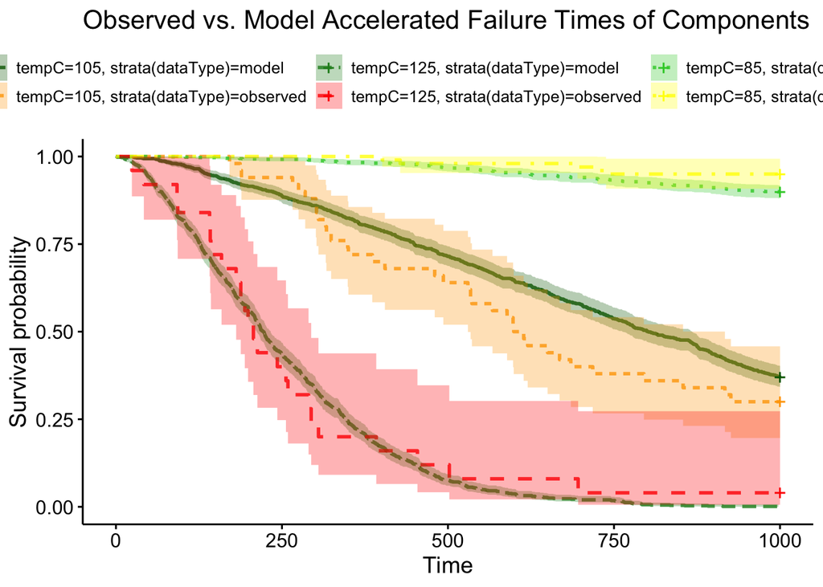

```r
ggsurvplot(fit = km.newds, data = newds, palette = c("darkgreen","orange", "forestgreen","red", "limegreen","yellow"), linetype = "strata", conf.int = T, alpha = .8) +
  labs(title = "Observed vs. Model Accelerated Failure Times of Components")
```

## N

Based on your plot, is your model a good match for the data? Why or why not?]

**ANSWER:** Based on the plot above, the model is a good match for the data because the model survival curves closely follow the survival curves produced by actual observations. The model data matches least with the observed data from the tempC = 105 strata.

## O

Assuming the use temperature condition is 25C, what is the acceleration factor if you run a reliability demonstration test at 65C?

```r
ea = b1

AF=exp(ea*(11605/(25+273.15) - 11605/(65+273.15)))
AF
```

```
## ds$arrTemp
##   50.34543
```

**ANSWER:** Acceleration factor of test at 65 C : 50.345

## P

Suppose you run an experiment at a stress level that yields an acceleration factor of 20. The failure time data from your experiment is well approximated by a Lognormal(4,0.25). The time unit of your experiment was days. What is the probability of a part failing within 2 years (730 days) at use conditions?

```r
plnorm(730/20,4,0.25)
```

```
## [1] 0.05361701
```

**ANSWER:** There is about a 5% chance of a part failing with 2 years at use conditions.